# Phillipsova krivulja u europodručju

Kratki nalaz u kojem nijedan broj nije upisan rukom

## Pitanje

Phillipsova krivulja tvrdi da su niža nezaposlenost i viša inflacija dvije strane istog stanja gospodarstva. Ovdje se ta tvrdnja gleda na 20 zemalja europodručja u razdoblju od 2014 do 2024 godine, dakle na 220 opažanja, i pita se vrijedi li jednako prije i poslije inflacijskog vala.

Podaci su dvije javne Eurostatove tablice. Prva je harmonizirani indeks potrošačkih cijena, a druga je stopa nezaposlenosti. Obje se preuzimaju skriptom `data/preuzmi.R` i nijedan broj u ovom tekstu nije upisan rukom.

## Rezultati

U specifikaciji s fiksnim učincima zemlje veza je negativna i jasna. Rast stope nezaposlenosti za jedan postotni bod prati pad inflacije za 0,61 postotna boda uz standardnu pogrešku 0,08. Krivulja dakle postoji i u ovom uzorku.

Kada se dodaju i fiksni učinci godine, koeficijent pada na 0,04 i prestaje biti razlučiv od nule uz p vrijednost 0,50. To nije proturječje nego odgovor na drugo pitanje. Godišnji učinci uklanjaju sve što je u nekoj godini zajedničko svim zemljama, a upravo je takav bio energetski šok. Ono što je ostalo je usporedba zemalja unutar iste godine, i tu veze gotovo nema.

Podjela uzorka pokazuje odakle to dolazi. U razdoblju do 2019. godine jedan postotni bod nezaposlenosti prati pad inflacije od 0,27 postotna boda, na 120 opažanja. Od 2021. godine nadalje isti pad iznosi 1,39 postotna boda, na 80 opažanja, dakle nekoliko puta strmije. Prosječna inflacija u europodručju dosegla je vrhunac od 10,2 posto u 2022. godini, dok je prosječna nezaposlenost u istom razdoblju pala s 11,7 na 6,1 posto.

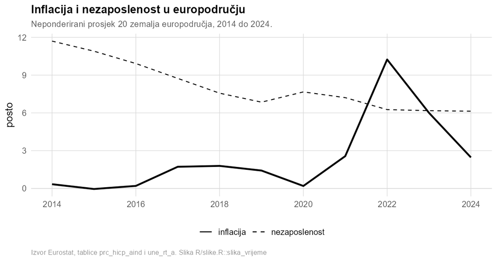

Inflacija i nezaposlenost u europodručju

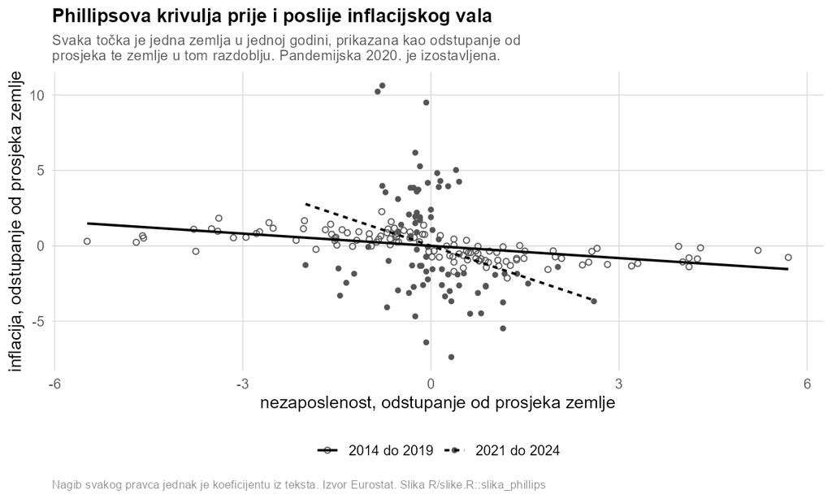

Phillipsova krivulja u dva razdoblja

## Ograničenja

Ovo je opisni nalaz, a ne procjena uzročnog učinka. Nezaposlenost nije slučajno dodijeljena i obje se veličine kreću zajedno s trećim stvarima, od cijena energije do tečaja. Strmiji nagib poslije 2021. godine ne znači da je Phillipsova veza ojačala nego da su u tom razdoblju zemlje s različitim tržištima rada različito primile isti vanjski šok.

Uzorak je namjerno malen i uravnotežen. Svrha ovog nalaza nije doprinos literaturi nego pokazni primjer za radionicu. Svaki broj u odjeljku Rezultati dolazi iz `results/procjene.json`, a taj se zapis gradi iz koda pri svakom pokretanju.